# TD7: Mankiw, Romer, Weil : Une application

Antoine Mayerowitz

29/11/2017

# Présentation

On cherche aujourd’hui à reproduire la méthode présentée dans l’article de Mankiw, Romer, and Weil (1990). Les auteurs cherchent à estimer le modèle de Solow (1988). Les deux hypothèses que l’ont cherche à tester sont:

- Plus le taux d’épargne est élevé, plus le pays sera riche.
- Plus la croissance de la population est élevée, plus le pays sera pauvre.

Nous allons ici nous limiter à l’estimation du modèle de Solow standard et laisser de côté le modèle augmenté du capital humain, je vous invite à lire l’article pour avoir plus d’informations à ce sujet.

L’équation que nous souhaitons estimer est la suivante:

$$\ln\left[\frac{Y}{L}\right] = c + \frac{\alpha}{1-\alpha}\ln(s) - \frac{\alpha}{1-\alpha}\ln(n+e+\delta) + \epsilon$$
Avec:

- $Y$ la production
- $L$ le travail
- $\alpha$ l’élasticité de la production au capital ($Y_t=K_t^\alpha (A_tL_t)^{1-\alpha}$)
- $n$ le taux de croissance de la population ($L_t=L_0e^{nt}$)
- $e$ le taux de croissance du progrès technique ($A_t=A_0e^{et}$)
- $\delta$ la dépreciation du capital
- $c$ une constante
- $\epsilon$ le terme d’erreur

La méthode se déroule en trois parties:

1. Créer notre base de données.
2. Visualiser nos données à travers des graphiques
3. Estimer l’équation du modèle

# Création de notre base de données

Je commence par déclarer quelques variables utiles pour la suite.

```r
> startDate <- 1970
> middleDate <- 1985
> endDate   <- 2014
>
> # Je mets ici la liste des pays de l'OCDE, j'en aurai besoin plus tard
> OECD_list <- c("BRA", "CHN", "COL", "CRI", "HUN", "IDN", "IND", "ISL", "LUX", "ZAF", "ARG", "AUS", "AUT", "BEL", "CAN", "CHE", "CHL", "DEU", "DNK", "ESP", "FIN", "FRA", "GBR", "GRC", "IRL", "ISR", "ITA", "JPN", "KOR", "MEX", "NLD", "NOR", "NZL", "POL", "PRT", "SWE", "TUR")
```

Je télécharge ensuite les données.

```r
url <- getURL('http://mayerowitz.io/download/pwt90.csv')
data <- read.csv(text = url, sep=";")
```

On isole les variables qui nous intéressent:

- countrycode
- country
- year
- rgdpo (Output-side real GDP at chained PPPs (in mil. 2011US$))
- cgdpo (Output-side real GDP ar current PPPs (in mil. 2011US$))
- ccon (Real consumption of households and government, at current PPPs (in mil. 2011US$))
- csh_i (Share of gross capital formation at current PPPs)
- pop (Population (in millions))
- delta (depreciation rate of physical capital)

```r
df <- as.data.frame(data) %>%
  select(countrycode, country, year, rgdpo, cgdpo, ccon, csh_i, pop, delta, hc)
```

On crée les variables dont on a besoin

```r
df <- df %>%
  mutate(s_proxy = (csh_i*cgdpo)/cgdpo, # Taux d'épargne
         rgdpoPop= rgdpo/pop,           # PIB/hab
         cconPop = ccon/pop,            # Conso/hab
         OECD    = ifelse(countrycode %in% OECD_list,1,0)) # Variable indicatrice pour les pays de l'OCDE
```

On supprime également les données qui précèdent 1970 et les pays pour lesquelles il y a une absence d’observations.

```r
df <- df %>%
  group_by(countrycode) %>%
  filter(!is.na(rgdpo),
         !is.na(delta),
         year >= startDate) %>%
  filter(min(year) == startDate)
```

On construit 2 bases de données pour les 2 horizons temporels différents : 1970-2014, 1970-1985. On veut donc pour chaque pays avoir la moyenne des variables sur l’horizon temporel choisi.

```r
df_7014 <- df %>%
  group_by(country, countrycode) %>%
  mutate(firstPop  = first(pop),
         lastPop   = last(pop),
         firstGdp  = first(rgdpo),
         lastGdp   = last(rgdpo),
         n = (lastPop/firstPop)^(1/(endDate-startDate)) -1,     #Taux de croissance annuel de la pop
         g = (lastGdp/firstGdp)^(1/(endDate-startDate)) -1) %>% #Taux de croissance annuel du PIB
  # On ne garde que la moyenne sur la période (puisque notre estimation est faire sur des données en coupe):
  summarise_all(mean) %>%
  mutate(lrgdpoPop = log(rgdpoPop),                   # log(Y/L)
         ls        = log(s_proxy),                    # log(s)
         lngd      = log(n+0.015+delta),              # log(n+e+delta)
         contr     = ls-lngd,                         # log(s)-log(n+g+delta) pour le modèle contraint
         oecd15K      = ifelse(OECD==1,ifelse(rgdpoPop >= 15000,1,0),0),
         lGdpPopFirst = log(firstGdp/firstPop),
         lGdpPopLast  = log(lastGdp/lastPop))

df_7085 <- df %>%
  group_by(country, countrycode) %>%
  filter(year <= middleDate) %>%
  mutate(firstPop  = first(pop),
         lastPop   = last(pop),
         firstGdp  = first(rgdpo),
         lastGdp   = last(rgdpo),
         n = (lastPop/firstPop)^(1/(middleDate-startDate)) -1,
         g = (lastGdp/firstGdp)^(1/(middleDate-startDate)) -1) %>%
  summarise_all(mean) %>%
  mutate(lrgdpoPop = log(rgdpoPop),
         ls        = log(s_proxy),
         lngd      = log(n+0.02+delta),
         contr     = ls-lngd,
         oecd15K   = ifelse(OECD==1,ifelse(rgdpoPop >= 15000,1,0),0))
```

## Un petit apperçu de la base:

```r
df_7014 %>% select(country, rgdpoPop, cconPop, n, g, s_proxy)
```

| country | rgdpoPop | cconPop | n | g | s_proxy |
| --- | --- | --- | --- | --- | --- |
| Albania | 5208.5176 | 4698.5414 | 0.0067361451 | 0.034768825 | 0.16737465 |
| Algeria | 9477.2961 | 5371.2124 | 0.0226221595 | 0.038051176 | 0.37280850 |
| Angola | 3941.9791 | 2331.6748 | 0.0310820355 | 0.046903953 | 0.33841055 |
| Anguilla | 17371.8044 | 12847.7374 | 0.0186973797 | 0.040177480 | 0.58721426 |
| Antigua and Barbuda | 10763.2542 | 10661.3800 | 0.0075215976 | 0.031693494 | 0.21604672 |
| Argentina | 9916.1649 | 8062.7356 | 0.0133567033 | 0.051415624 | 0.16099933 |
| Aruba | 32064.0349 | 19565.2435 | 0.0128169619 | 0.051654031 | 0.42210510 |
| Australia | 30188.3585 | 21730.0897 | 0.0138356845 | 0.033476072 | 0.28174298 |
| Austria | 26856.9400 | 20326.6634 | 0.0028643822 | 0.031707706 | 0.28287410 |
| Bahamas | 19570.4515 | 15565.3356 | 0.0187224941 | 0.022288623 | 0.18492422 |

[output cut: 146 more lines]

# Quelques graphs

On commence par observer notre base de données pour comprendre la relation entre nos variables avant de passer à l’estimation.

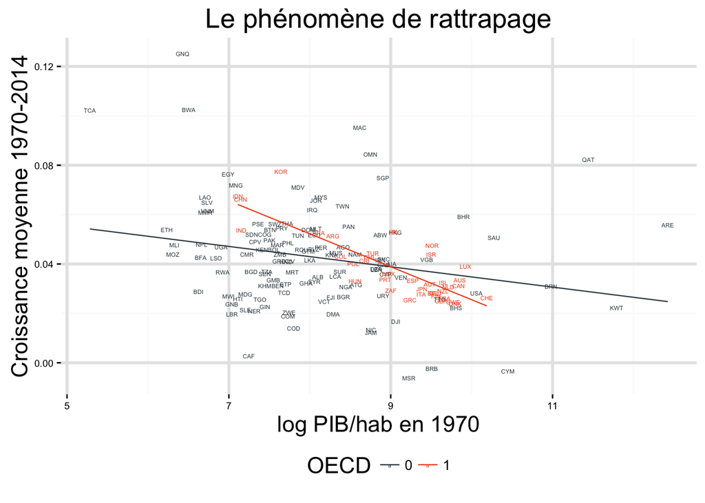

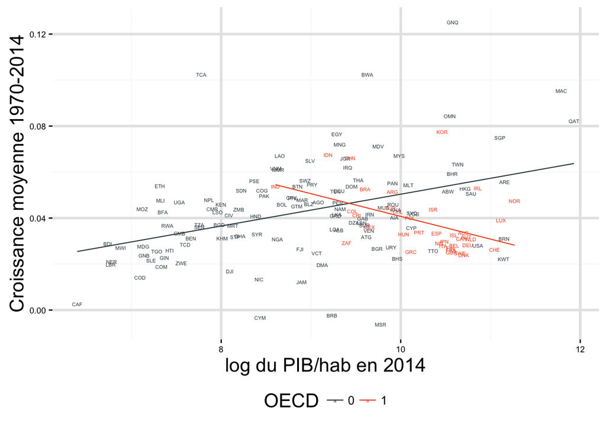

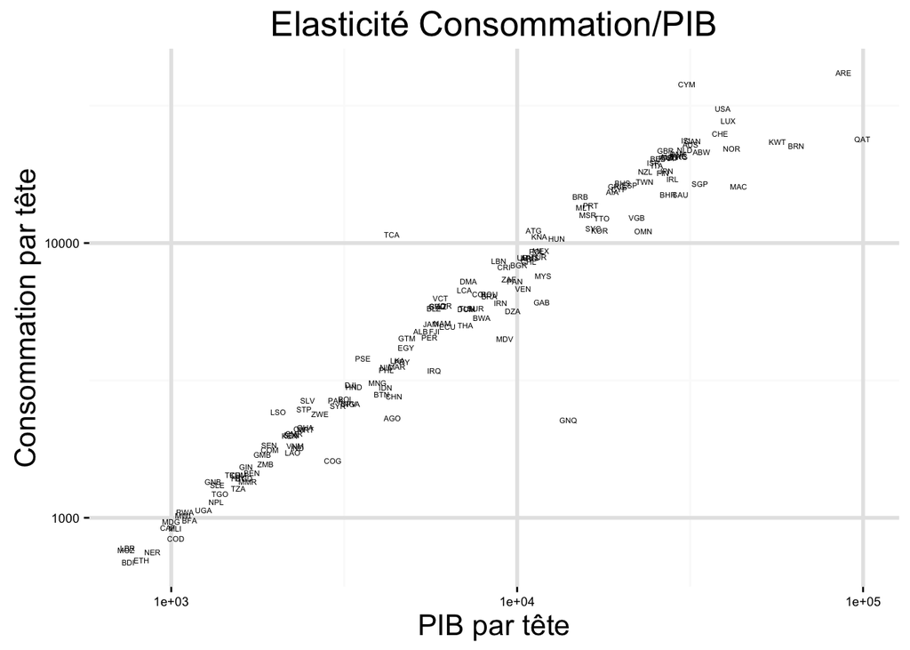

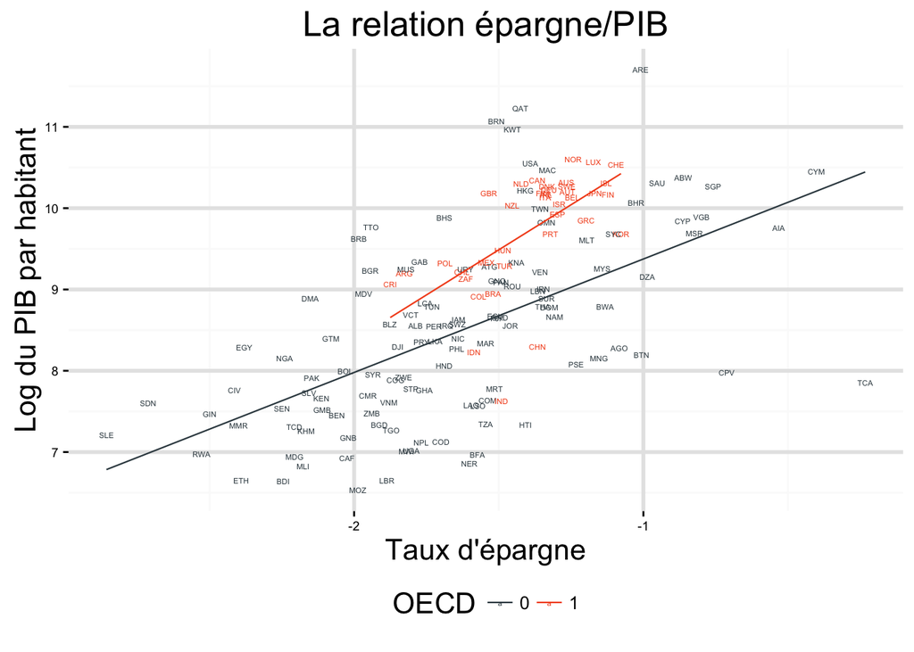

# Les régressions

## Sur la période 1970-2014

```r
fit.all.stand <- lm(lrgdpoPop ~ ls + lngd, data=df_7014) # Tous les pays, pas de contraint
fit.all.oecd <- lm(lrgdpoPop ~ ls + lngd, data=df_7014, subset = (OECD==1)) # OCDE, pas de contrainte
fit.all.constr <- lm(lrgdpoPop ~ contr, data=df_7014) # Tous les pays, modèle contraint
fit.all.constr.oecd <- lm(lrgdpoPop ~ contr, data=df_7014, subset = (OECD==1)) # OCDE, modèle contraint
```

|  | **All cntry** | **OECD** | **All, restricted** | **OECD, restricted** |  |
| --- | --- | --- | --- | --- | --- |
| Constante | 10.36*** | 9.78*** | 7.45*** | 7.67*** |  |
|  | (1.09) | (2.15) | (0.18) | (0.44) |  |
| ln(i/gdp) | 1.69*** | 1.98*** |  |  |  |
|  | (0.19) | (0.50) |  |  |  |
| ln(n+e+d) | -0.44 | -1.01 |  |  |  |
|  | (0.40) | (0.68) |  |  |  |
| ln(i/gdp)-ln(n+e+d) |  |  | 1.42*** | 1.61*** |  |
|  |  |  | (0.16) | (0.34) |  |
| R<sup>2</sup> | 0.36 | 0.41 | 0.33 | 0.40 |  |
| Adj. R<sup>2</sup> | 0.35 | 0.38 | 0.33 | 0.38 |  |
| Num. obs. | 156 | 37 | 156 | 37 |  |
| RMSE | 1.01 | 0.56 | 1.03 | 0.56 |  |
| ***p < 0.001, **p < 0.01, *p < 0.05 |  |  |  |  |  |

## Sur la période 1970-1985

```r
fit.all.stand <- lm(lrgdpoPop ~ ls + lngd, data=df_7085)
fit.all.oecd <- lm(lrgdpoPop ~ ls + lngd, data=df_7085, subset = (OECD==1))
fit.all.constr <- lm(lrgdpoPop ~ contr, data=df_7085)
fit.all.constr.oecd <- lm(lrgdpoPop ~ contr, data=df_7085, subset = (OECD==1))
```

|  | **All cntry** | **OECD** | **All, restricted** | **OECD, restricted** |  |
| --- | --- | --- | --- | --- | --- |
| Constante | 9.87*** | 8.85*** | 7.83*** | 7.50*** |  |
|  | (1.08) | (1.88) | (0.14) | (0.33) |  |
| ln(i/gdp) | 0.95*** | 1.64*** |  |  |  |
|  | (0.14) | (0.34) |  |  |  |
| ln(n+e+d) | -0.09 | -1.04 |  |  |  |
|  | (0.43) | (0.67) |  |  |  |
| ln(i/gdp)-ln(n+e+d) |  |  | 0.86*** | 1.49*** |  |
|  |  |  | (0.13) | (0.26) |  |
| R<sup>2</sup> | 0.23 | 0.48 | 0.22 | 0.47 |  |
| Adj. R<sup>2</sup> | 0.22 | 0.45 | 0.21 | 0.46 |  |
| Num. obs. | 156 | 37 | 156 | 37 |  |
| RMSE | 1.11 | 0.58 | 1.12 | 0.57 |  |
| ***p < 0.001, **p < 0.01, *p < 0.05 |  |  |  |  |  |

# Bibliography

Mankiw, N.Gregory, David Romer, and David N. Weil. 1990. “A Contribution to the Empirics of Economic Growth.” NBER Working Paper.

Solow, Robert M. 1988. “A Contribution to the Theory of Economic Growth.” Quarterly Journal of Economics.